# Introduction to R (Completed Notebook)

R for Data Science

LDG

# 1 R The calculator

The simplest way to use R is as a calculator.

For example, the code below calculates $1+1$. Click “run” (the green play button) to see:

```r
1+1 # add one and one
```

```
[1] 2
```

Notice the part after “#” (inside a code chunk) is not executed because it as a **comment.** Write comments to remind yourself (or rather, your future self, who will read the code later) what the code does.

Here is another example. This code calculates $2^3 + 4 \times 5 + \frac{5}{6}$:

```r
2^3 + 4*5 + 5/6 # two to the third plus four times five plus five divided by six
```

```
[1] 28.83333
```

## 1.1 Checkpoint

Calculate $2^2 \times 3^3$:

```r
2^2 * 3^3
```

```
[1] 108
```

Calculate $2/3 + 4/5 + 6/7$:

```r
2/3 + 4/5 + 6/7
```

```
[1] 2.32381
```

Calculate $2^3 + 4*5 + 6^7$:

```r
2^3 + 4*5 + 6^7
```

```
[1] 279964
```

## 1.2 Objects

OK, we can use R to make calculations.

But what if we want to save the output of one calculation and use it in another calculation?

R has memory. What does it remember? Whatever you tell it to! This is called **defining objects**.

Suppose we want to calculate $1+1$ and store it in an object. We have to give it a name. Let’s call it “x”:

```r
x = 1 + 1
```

Notice two things:

1. `=` is the **assignment operator**. It says: "take 1+1 and assign its *output* to `x`.
2. When we run the code, `x = 1 + 1`, nothing spits out. That’s because the output is **stored** in `x`.

What happens if we calculate $x+2$

```r
x + 2
```

```
[1] 4
```

It’s the same as calculating $(1+1)+2$.

Let’s create another object called “my_object” equal to $x \times 4$:

```r
my_object = x * 4
```

## 1.3 Vectors

Vectors are objects with multiple values.

```r
my_vector = c(1,2,3,4) # create a vector
my_vector # then print it to the screen
```

```
[1] 1 2 3 4
```

We can multiply each value by 2:

```r
my_vector * 2
```

```
[1] 2 4 6 8
```

and we multiply each value by 2 and create a new vector (e.g., “data_new_vector”):

```r
data_new_vector = my_vector * 2
```

Vectors can also contain words – also referred to as “strings” or “characters”.

For instance, here is a vector with the words “hello” and “world”:

```r
character_vector <- c("hello", "world") # make the vector
character_vector # view it!
```

```
[1] "hello" "world"
```

## 1.4 Functions

Objects are nouns. Functions are verbs, acting on those nouns. That is programming in R in a nutshell. You have a data set (object). You do things to that data set (e.g., analyze with functions).

All functions in R have parentheses: `function()`. When we created a vector we used the function `c()`.

If we have a vector of data, like `data_new_vector`, we can calculate the sum with `sum()`:

```r
sum(data_new_vector)
```

```
[1] 20
```

Or find the maximum value with `max()`:

```r
max(data_new_vector)
```

```
[1] 8
```

Or find the minimum value with `min()`:

```r
min(data_new_vector)
```

```
[1] 2
```

Or calculate the average or mean with `mean()`:

```r
mean(data_new_vector)
```

```
[1] 5
```

## 1.5 Checkpoint

Recall that you create a vector with `c()` and assign it with `=`. For example, the chunk below creates a vector called “v” with values $1,2,3$:

```r
v = c(1,2,3)
```

Create a vector called “x” with the values $5, 9, 4, 8, 40, 22$:

```r
x <- c(5,9,4,8,40,22)
```

Multiply `x` by 2:

```r
x*2
```

```
[1] 10 18  8 16 80 44
```

Calculate the sum of `x` with the function `sum()`:

```r
sum(x)
```

```
[1] 88
```

Calculate the average of `x` with `mean()`:

```r
mean(x)
```

```
[1] 14.66667
```

Calculate the median of `x` with `median()`:

```r
median(x)
```

```
[1] 8.5
```

Calculate the standard deviation of `x` with `sd()`:

```r
sd(x)
```

```
[1] 13.99524
```

# 2 Dataframes

Dataframes – like what you see in an Excel sheet – are just vectors chained together.

Let’s load the `tidyverse`:

```r
library(tidyverse)
```

and then load a built-in dataset called “diamonds” with prices of over 50,000 round cut diamonds:

```r
data("diamonds") # use the function data() to load a built-in dataset
```

You can view the data inside the notebook like so:

```r
diamonds
```

| carat | cut | color | clarity | depth | table | price | x | y | z |
| --- | --- | --- | --- | --- | --- | --- | --- | --- | --- |
| 0.23 | Ideal | E | SI2 | 61.5 | 55.0 | 326 | 3.95 | 3.98 | 2.43 |
| 0.21 | Premium | E | SI1 | 59.8 | 61.0 | 326 | 3.89 | 3.84 | 2.31 |
| 0.23 | Good | E | VS1 | 56.9 | 65.0 | 327 | 4.05 | 4.07 | 2.31 |
| 0.29 | Premium | I | VS2 | 62.4 | 58.0 | 334 | 4.20 | 4.23 | 2.63 |
| 0.31 | Good | J | SI2 | 63.3 | 58.0 | 335 | 4.34 | 4.35 | 2.75 |
| 0.24 | Very Good | J | VVS2 | 62.8 | 57.0 | 336 | 3.94 | 3.96 | 2.48 |
| 0.24 | Very Good | I | VVS1 | 62.3 | 57.0 | 336 | 3.95 | 3.98 | 2.47 |
| 0.26 | Very Good | H | SI1 | 61.9 | 55.0 | 337 | 4.07 | 4.11 | 2.53 |
| 0.22 | Fair | E | VS2 | 65.1 | 61.0 | 337 | 3.87 | 3.78 | 2.49 |
| 0.23 | Very Good | H | VS1 | 59.4 | 61.0 | 338 | 4.00 | 4.05 | 2.39 |

[output cut: 990 more lines]

or you can click on in the “Environment” window pane in the top-right corner of RStudio.

Notice the data contains a variety of data **types**, such as:

- `price`, `carat`, `depth`, `table`: continuous, numerical variables (scale: ratio)
- `color`: categorical variable (scale: nominal, i.e. a classification with no ranking)
- `cut`: categorical variable (scale: ordinal, i.e. you can rank them)

## 2.1 Summarizing data

In R those two steps are:

```r
diamonds %>% # take the data, THEN
  summarise(mean(price)) # summarize it by calculating average price
```

| mean(price) |
| --- |
| 3932.8 |

But not all diamonds are created equal! (According to De Beers.)

Let’s group diamonds by their `cut` `class` and then calculate the mean price:

```r
diamonds %>% # take the data, THEN
  group_by(cut) %>%  # group the diamonds by cut, THEN
  summarise(mean(price)) # summarize the data by calculating average price by cut
```

| cut | mean(price) |
| --- | --- |
| Fair | 4358.758 |
| Good | 3928.864 |
| Very Good | 3981.760 |
| Premium | 4584.258 |
| Ideal | 3457.542 |

### 2.1.1 Checkpoint

Group the diamonds by clarity (`clarity`) and then calculate average price:

```r
diamonds %>%
  group_by(clarity) %>%
  summarise(mean(price))
```

| clarity | mean(price) |
| --- | --- |
| I1 | 3924.169 |
| SI2 | 5063.029 |
| SI1 | 3996.001 |
| VS2 | 3924.989 |
| VS1 | 3839.455 |
| VVS2 | 3283.737 |
| VVS1 | 2523.115 |
| IF | 2864.839 |

Now group diamonds by `cut` and calculate average (`mean()`), median (`median()`) and standard deviation (`sd()`) price. Hint: you only need one call to `summarise()`!

```r
diamonds %>%
  group_by(cut) %>%
  summarise(mean(price), median(price), sd(price))
```

| cut | mean(price) | median(price) | sd(price) |
| --- | --- | --- | --- |
| Fair | 4358.758 | 3282.0 | 3560.387 |
| Good | 3928.864 | 3050.5 | 3681.590 |
| Very Good | 3981.760 | 2648.0 | 3935.862 |
| Premium | 4584.258 | 3185.0 | 4349.205 |
| Ideal | 3457.542 | 1810.0 | 3808.401 |

## 2.2 Visualizing data

One of the most important plots is the **histogram**. This tells you how observations are **distributed**. Understanding distributions is the bedrock of statistical modeling.

Let’s plot the **distribution** of prices:

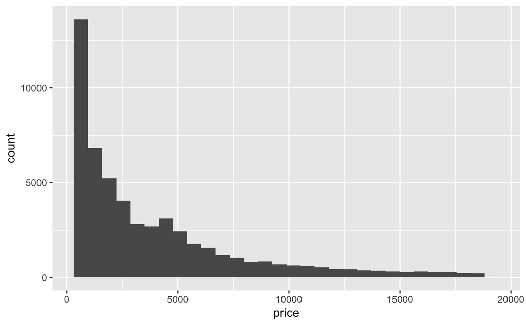

```r
ggplot(data = diamonds, aes(x = price)) +
  geom_histogram()
```

The distribution is heavily skewed. Clearly the **average price** is not meaningful! Why? Because if you were to randomly draw from this distribution, you would not get a diamond close to the average.

To see this let’s re-plot the distribution but now with a vertical line at the average price:

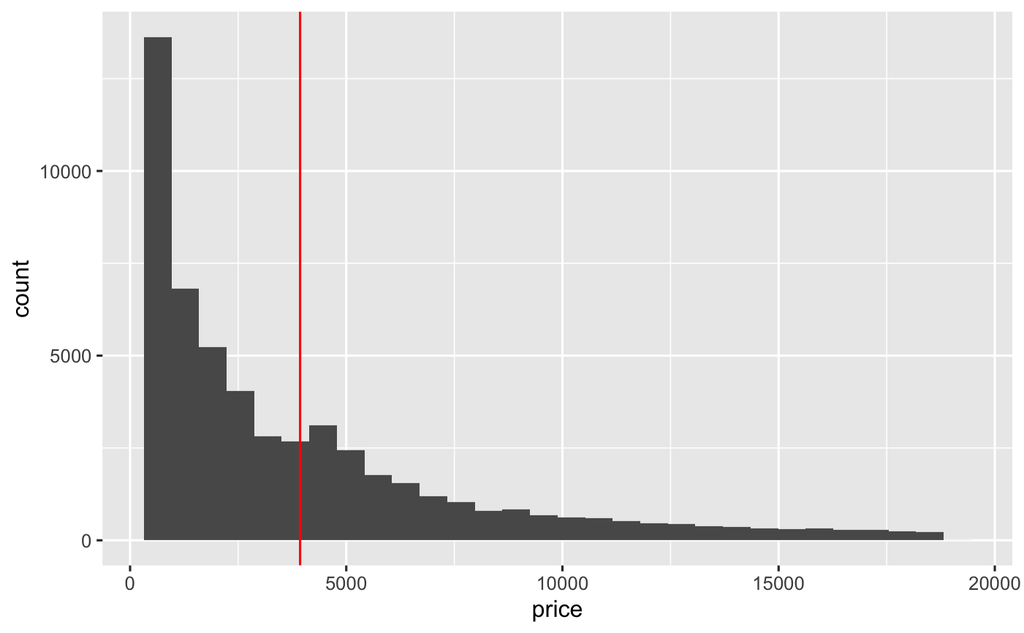

```r
ggplot(data = diamonds, aes(x = price)) +
  geom_histogram() +
  geom_vline(xintercept = 3932.8, color = "red")
```

Another key plot type is the **scatter plot**. Use this to study **relationships**.

Is there a relationship between a diamond’s carats (`carat`) and its price?

We might think about a model in which carats determine prices (and not the other way round). That is, prices are a **function** of carats:

$$\text{price} = f(\text{carats})$$
This model implies `carat` should be on the x-axis and `price` on the y-axis:

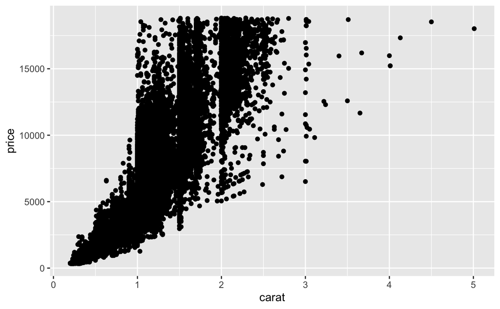

```r
ggplot(data = diamonds, aes(x = carat, y = price)) +
  geom_point()
```

Looks so!

### 2.2.1 Checkpoint

Plot the distribution of `table` (another diamond attribute)L

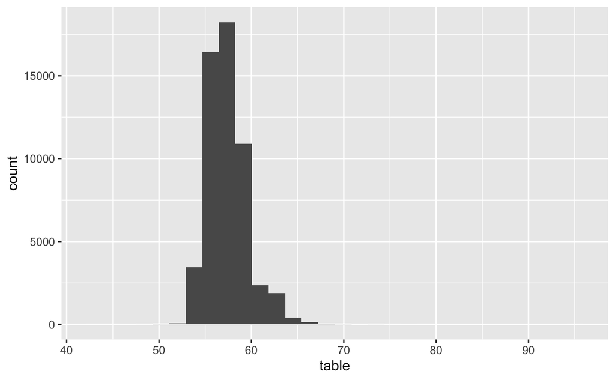

```r
ggplot(data = diamonds, aes(x = table)) +
  geom_histogram()
```

Replicate the code above but now plot the distribution of `depth` with `geom_density()` so you have kernel density estimate (basically a smooth histogram):

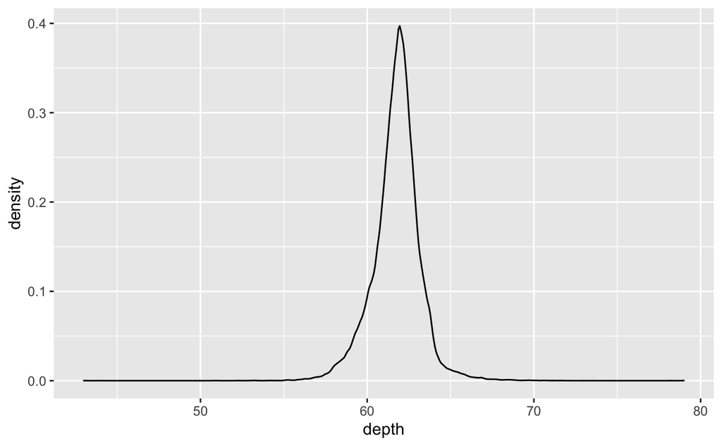

```r
ggplot(data = diamonds, aes(x = depth)) +
  geom_density()
```

Based on this plot do you think the average depth of a diamond is meaningful?

## 2.3 Plots by category

Many times we care about outcomes conditional on some category.

Just like `dplyr` makes it easy to `ggplot` makes it very easy to plot by a grouping variables.

There are two approaches.

### 2.3.1 Fill and color

First, create a single panel, and `fill` (histograms, boxplots, kernel densities) or `color` (scatter plots) by the group:

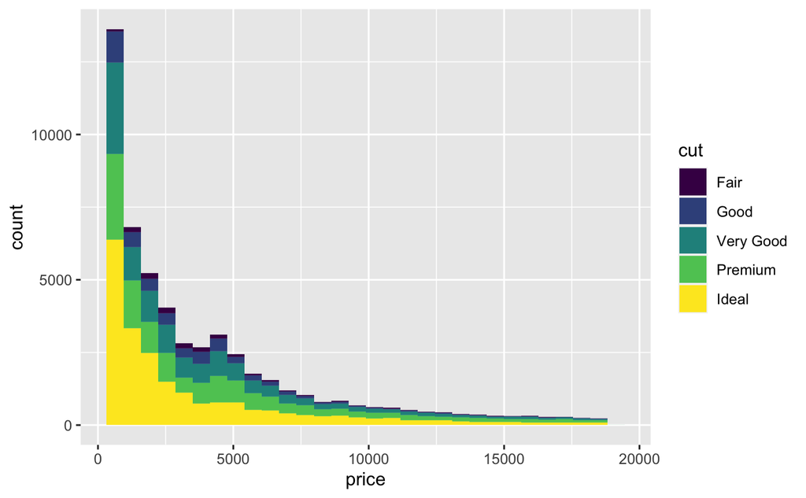

```r
ggplot(data = diamonds, aes(x = price, fill = cut)) +
  geom_histogram()
```

and for a scatterplot:

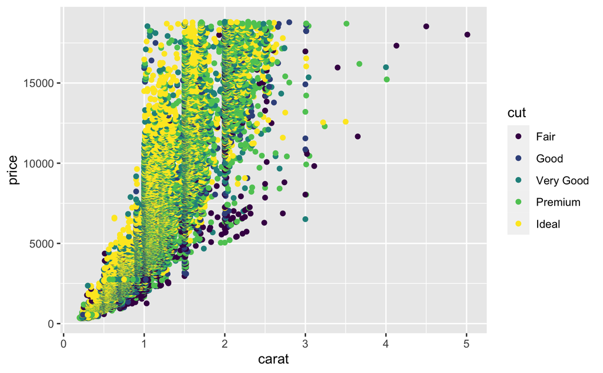

```r
ggplot(data = diamonds, aes(x = carat, y = price, color = cut)) +
  geom_point()
```

### 2.3.2 Facetting

But these types of plots are usually hard to read

Instead you can put each group in its own panel with `facet_wrap()`:

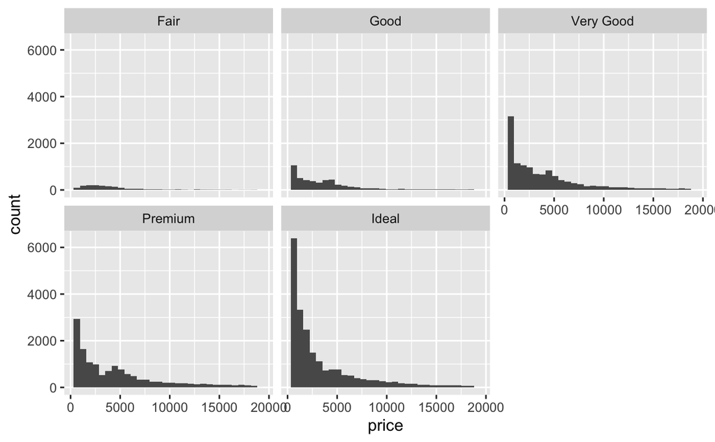

```r
ggplot(data = diamonds, aes(x = price)) +
  geom_histogram() +
  facet_wrap(~cut)
```

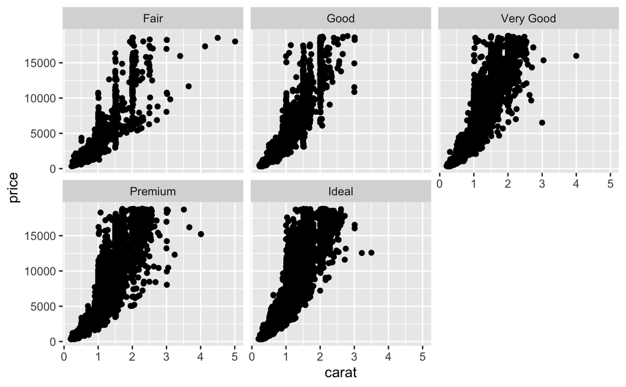

```r
ggplot(data = diamonds, aes(x = carat, y = price)) +
  geom_point() +
  facet_wrap(~cut) # note the "~" before the grouping variable
```

or you can even make a **grid** of plots by two categories using `facet_grid()`:

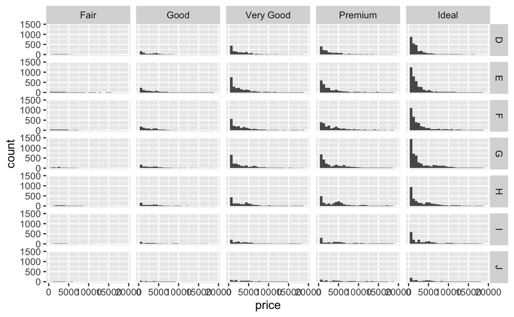

```r
ggplot(data = diamonds, aes(x = price)) +
  geom_histogram() +
  facet_grid(color~cut)
```